# COMPLETE RowRemoved Data Set

Theresa Van

December 6, 2018

## Row-Removed Data Set

This data set will delete any observations containing a ‘?’ and work with the full amount of predictors. We also decide to remove the predictors: “community”, “community name”, and “county” as that data is not relevant to our model.

```r
#load data file into crime
crime <- read.csv("communitiesandcrime.csv")

#remove column with community names
crime <- crime[,-c(2,3,4)]

#create an empty vector that will hold rows to be deleted
removeRow <- c()

#find which rows contain "?" and append the row number to removeCol vector
for(i in 1:nrow(crime))
{
  if (length(which(crime[i,] == "?")) != 0)
    removeRow <- c(removeRow, i)
}

#remove said columns
crime <- crime[-removeRow,]

#forcing all predictors to be numeric
for (i in 1:ncol(crime)){
  crime[,i]<-as.numeric(crime[,i])
}
```

We are now left with 319 observations from the original 1994 observations and 125 variables.

##### *Testing for collinearity:*

We are going to use the VIF factor to detect multicollinearity. The code below will detect the predictor with the highest VIF value, remove it, recalculate the VIF values for all remaining predictors, and repeat until all the remaining predictors have a VIF value below 10.

```r
library(usdm)
max.vif <- vif(crime)$VIF[which.max(vif(crime)$VIF)]

while(max.vif >= 10)
{
  if(max.vif >= 10)
    crime <- crime[,-which.max(vif(crime)$VIF)]
  max.vif <- vif(crime)$VIF[which.max(vif(crime)$VIF)]
}
```

##### *Splitting the data into a training set and a test set:*

We split 50% of the data into a test set and the other 50% into a training set.

```r
set.seed(1)

library(ISLR)
# proprtion divided into training and test sets
fractionTraining <- 0.5
fractionTesting <- 0.5

# gather sample size for training and test sets
nTraining <- floor(fractionTraining*nrow(Default))
nTest <- floor(fractionTesting*nrow(Default))

# find indices for training and test sets
indicesTraining <- sort(sample(1:nrow(Default),size=nTraining))
indicesTesting <- setdiff(1:nrow(Default), indicesTraining)

#creating the test set
crimeTesting <- crime[-c(indicesTraining),]

#creating the training set
crimeTraining <- crime[-c(indicesTesting),]
```

## Fitting the full linear model

```r
full.fit <- lm(ViolentCrimesPerPop~., data=crimeTraining)
summary(full.fit)
```

```
##
## Call:
## lm(formula = ViolentCrimesPerPop ~ ., data = crimeTraining)
##
## Residuals:
##      Min       1Q   Median       3Q      Max
## -0.46887 -0.08661 -0.01423  0.08091  0.49327
##
## Coefficients:
##                         Estimate Std. Error t value Pr(>|t|)
## (Intercept)           -0.3188830  0.6153309  -0.518   0.6053
## state                 -0.0028839  0.0012539  -2.300   0.0233 *
## fold                  -0.0030639  0.0056575  -0.542   0.5892
## racePctAsian          -0.0486872  0.1304930  -0.373   0.7098
## agePct12t21           -0.1713050  0.3003603  -0.570   0.5696
## agePct65up             0.5200019  0.2955727   1.759   0.0812 .
## pctUrban               0.2285150  0.2446414   0.934   0.3522
## pctWFarmSelf          -0.0231122  0.2128677  -0.109   0.9137
## pctWRetire            -0.1348938  0.2115249  -0.638   0.5249
## WhitePerCap           -0.0704018  0.2220359  -0.317   0.7518
## BlackPerCap           -0.3411315  0.2861763  -1.192   0.2357
## IndianPerCap           0.2837275  0.2667084   1.064   0.2897
## AsianPerCap           -0.0627890  0.1742658  -0.360   0.7193
## OtherPerCap           -0.0010194  0.0019348  -0.527   0.5993
## HispPerCap             0.1056301  0.2677121   0.395   0.6939
## PctLess9thGrade       -0.2768700  0.2189220  -1.265   0.2086
## PctUnemployed          0.2261626  0.2406582   0.940   0.3493
## PctEmplManu           -0.1405883  0.1555285  -0.904   0.3679
## PctEmplProfServ       -0.0378886  0.2166982  -0.175   0.8615
## MalePctDivorce         0.0826718  0.2170424   0.381   0.7040
## MalePctNevMarr         0.3793304  0.2661098   1.425   0.1568
## PctWorkMomYoungKids    0.0156857  0.1704922   0.092   0.9269
## NumIlleg               0.1989900  0.2079745   0.957   0.3407
## NumImmig              -0.0756654  0.2132750  -0.355   0.7234
## PctImmigRecent        -0.2007757  0.2140975  -0.938   0.3503
## PctImmigRec10          0.4021755  0.2749025   1.463   0.1462
## PersPerOwnOccHous      0.1531237  0.2766099   0.554   0.5810
## PersPerRentOccHous     0.2310916  0.2684907   0.861   0.3912
## PctHousLess3BR        -0.1168211  0.3607270  -0.324   0.7466
## MedNumBR               0.0173750  0.1057185   0.164   0.8697
```

[output cut: 23 more lines]

```
## PolicAveOTWorked      -0.0005995  0.0009803  -0.612   0.5420
## LandArea              -0.1316896  0.1566130  -0.841   0.4022
## PopDens               -0.1010340  0.1436887  -0.703   0.4834
## PctUsePubTrans        -0.0258334  0.1236366  -0.209   0.8349
## PolicCars              0.0012213  0.0024957   0.489   0.6255
## LemasPctPolicOnPatr   -0.0001338  0.0010589  -0.126   0.8996
## LemasGangUnitDeploy    0.0103493  0.0210393   0.492   0.6237
## LemasPctOfficDrugUn    0.0047003  0.0948823   0.050   0.9606
## PolicBudgPerPop       -0.0042757  0.0043544  -0.982   0.3282
## ---
## Signif. codes:  0 '***' 0.001 '**' 0.01 '*' 0.05 '.' 0.1 ' ' 1
##
## Residual standard error: 0.1838 on 114 degrees of freedom
## Multiple R-squared:  0.722,  Adjusted R-squared:  0.5732
## F-statistic: 4.853 on 61 and 114 DF,  p-value: 1.978e-13
```

### *Fitting the full linear model with state interaction terms*

```r
state.int.fit <- lm(ViolentCrimesPerPop~.+state:., data=crimeTraining)
summary(state.int.fit)
```

```
##
## Call:
## lm(formula = ViolentCrimesPerPop ~ . + state:., data = crimeTraining)
##
## Residuals:
##       Min        1Q    Median        3Q       Max
## -0.218586 -0.062043  0.001927  0.052958  0.266214
##
## Coefficients:
##                               Estimate Std. Error t value Pr(>|t|)
## (Intercept)                  1.554e+00  6.762e+00   0.230   0.8191
## state                       -6.208e-03  1.419e-01  -0.044   0.9653
## fold                         1.034e-02  1.332e-02   0.776   0.4410
## racePctAsian                -1.372e-01  2.896e-01  -0.474   0.6375
## agePct12t21                  4.533e-01  9.201e-01   0.493   0.6243
## agePct65up                   1.958e+00  9.209e-01   2.126   0.0381 *
## pctUrban                    -3.678e+00  6.234e+00  -0.590   0.5577
## pctWFarmSelf                 1.150e+00  8.017e-01   1.435   0.1571
## pctWRetire                   5.228e-01  5.028e-01   1.040   0.3030
## WhitePerCap                 -1.587e-02  5.976e-01  -0.027   0.9789
## BlackPerCap                 -6.126e-01  7.430e-01  -0.825   0.4133
## IndianPerCap                 1.397e+00  7.146e-01   1.955   0.0558 .
## AsianPerCap                  5.042e-01  4.993e-01   1.010   0.3171
## OtherPerCap                 -1.069e-03  5.703e-03  -0.188   0.8520
## HispPerCap                  -6.467e-01  7.437e-01  -0.870   0.3884
## PctLess9thGrade             -2.085e-01  7.313e-01  -0.285   0.7766
## PctUnemployed                1.462e+00  6.519e-01   2.242   0.0291 *
## PctEmplManu                 -1.354e-01  4.371e-01  -0.310   0.7580
## PctEmplProfServ              1.815e-01  6.219e-01   0.292   0.7716
## MalePctDivorce               7.063e-01  7.666e-01   0.921   0.3610
## MalePctNevMarr               5.735e-01  8.217e-01   0.698   0.4882
## PctWorkMomYoungKids          3.666e-01  4.859e-01   0.755   0.4538
## NumIlleg                    -5.990e-01  6.393e-01  -0.937   0.3530
## NumImmig                    -5.686e-01  5.405e-01  -1.052   0.2976
## PctImmigRecent              -1.447e+00  6.334e-01  -2.284   0.0263 *
## PctImmigRec10                2.005e+00  8.238e-01   2.434   0.0183 *
## PersPerOwnOccHous            2.303e+00  9.476e-01   2.431   0.0184 *
## PersPerRentOccHous          -8.710e-01  7.913e-01  -1.101   0.2759
## PctHousLess3BR              -4.191e-01  1.216e+00  -0.345   0.7318
## MedNumBR                     3.475e-01  2.859e-01   1.216   0.2294
```

[output cut: 83 more lines]

```
## state:PolicAveOTWorked       7.540e-05  8.357e-05   0.902   0.3709
## state:LandArea               2.007e-04  1.611e-02   0.012   0.9901
## state:PopDens               -3.539e-03  1.478e-02  -0.239   0.8117
## state:PctUsePubTrans         1.064e-03  1.478e-02   0.072   0.9428
## state:PolicCars              2.777e-04  2.079e-04   1.336   0.1873
## state:LemasPctPolicOnPatr    1.260e-04  9.943e-05   1.267   0.2105
## state:LemasGangUnitDeploy    7.168e-04  1.874e-03   0.382   0.7036
## state:LemasPctOfficDrugUn    1.237e-02  8.735e-03   1.416   0.1626
## state:PolicBudgPerPop       -3.488e-04  4.178e-04  -0.835   0.4075
## ---
## Signif. codes:  0 '***' 0.001 '**' 0.01 '*' 0.05 '.' 0.1 ' ' 1
##
## Residual standard error: 0.1687 on 54 degrees of freedom
## Multiple R-squared:  0.889,  Adjusted R-squared:  0.6402
## F-statistic: 3.573 on 121 and 54 DF,  p-value: 4.006e-07
```

There is an increase in R-squared and adjusted R-squared with state interaction terms from the original model: 0.722 -> 0.889 for R-squared and 0.5732 -> 0.6402. However if we include state interaction terms, we would forgo model interpretability so we decide to abandon state interaction terms as a potential model assessment.

#### *Residual plots for the full linear model**

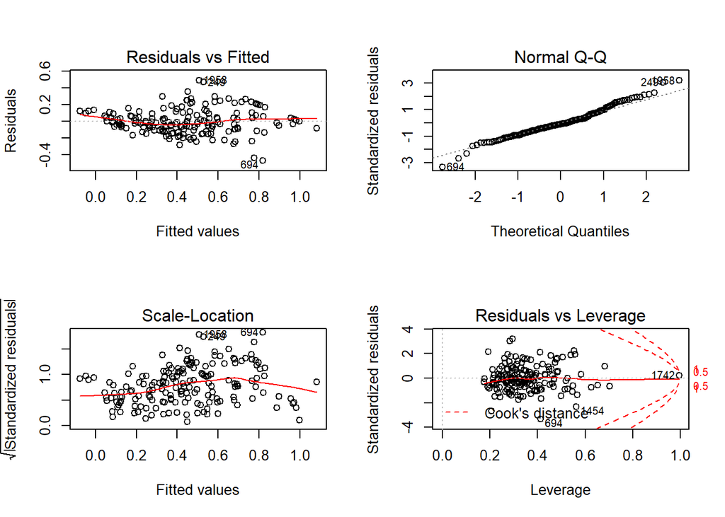

```r
par(mfrow=c(2,2))
plot(full.fit)
```

## Forward Stepwise Regression

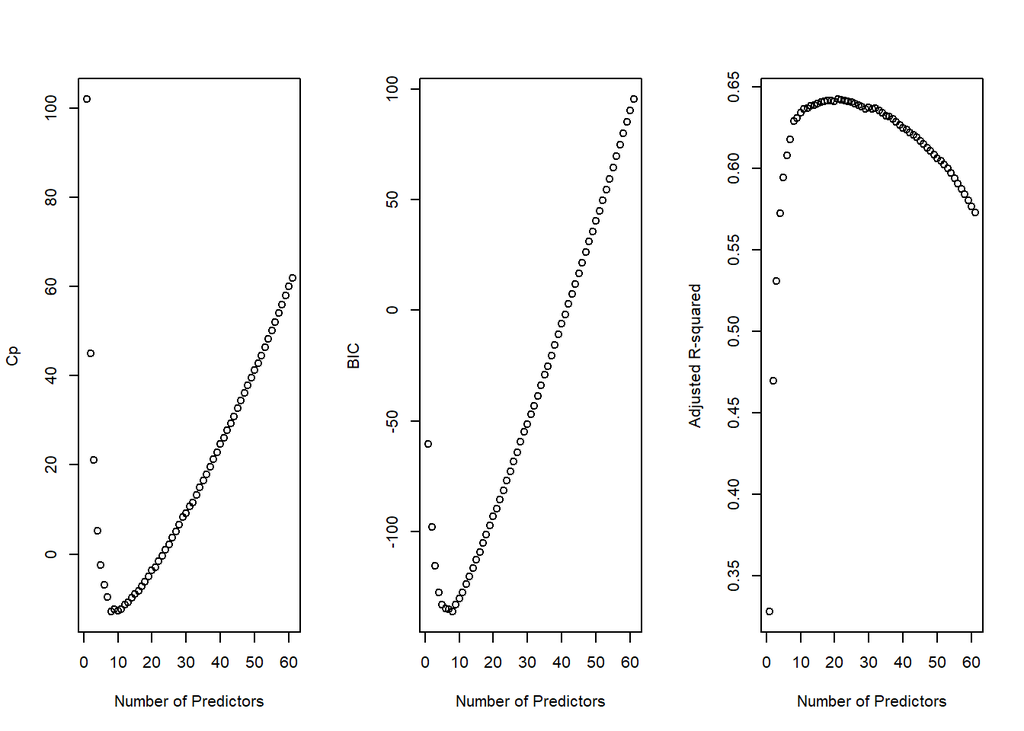

```r
library(leaps)

crime.forward <- regsubsets(ViolentCrimesPerPop~., data=crimeTraining, method = "forward", nvmax = 62, really.big = TRUE)

resforward <- summary(crime.forward)

par(mfrow=c(1,3))
plot(1:61, resforward$cp, xlab = "Number of Predictors", ylab = "Cp")
plot(1:61, resforward$bic, xlab = "Number of Predictors", ylab = "BIC")
plot(1:61, resforward$adjr2, xlab = "Number of Predictors", ylab = "Adjusted R-squared")
```

```r
which.min(resforward$cp) #tells us which n-variable model gives us the lowest Cp value
```

```
## [1] 8
```

```r
which.min(resforward$bic) #tells us which n-variable model gives us the lowest BIC value
```

```
## [1] 8
```

```r
which.max(resforward$adjr2) #tells us which n-variable model gives us the highest adjusted r-squared value
```

```
## [1] 21
```

### **Model 1: best Cp & BIC model**

Cp and BIC give us the same 8-variable model.

```r
coef(crime.forward,8)
```

```
##        (Intercept)              state      PctUnemployed
##        0.054502684       -0.002501221        0.114097054
##     PctHousLess3BR   PctVacantBoarded     PctHousNoPhone
##        0.484803315        0.164378139        0.250277079
##          NumStreet RacialMatchCommPol      PctPolicBlack
##        0.201298705       -0.002746517        0.003321846
```

```r
fit.cp.bic <- lm(ViolentCrimesPerPop~state+PctUnemployed+PctHousLess3BR+PctVacantBoarded+PctHousNoPhone+NumStreet+RacialMatchCommPol+PctPolicBlack, data=crimeTraining)
summary(fit.cp.bic)
```

```
##
## Call:
## lm(formula = ViolentCrimesPerPop ~ state + PctUnemployed + PctHousLess3BR +
##     PctVacantBoarded + PctHousNoPhone + NumStreet + RacialMatchCommPol +
##     PctPolicBlack, data = crimeTraining)
##
## Residuals:
##      Min       1Q   Median       3Q      Max
## -0.48029 -0.10029 -0.02161  0.09658  0.42260
##
## Coefficients:
##                      Estimate Std. Error t value Pr(>|t|)
## (Intercept)         0.0545027  0.0772367   0.706 0.481384
## state              -0.0025012  0.0008265  -3.026 0.002867 **
## PctUnemployed       0.1140971  0.1099407   1.038 0.300861
## PctHousLess3BR      0.4848033  0.1133150   4.278 3.16e-05 ***
## PctVacantBoarded    0.1643781  0.0636647   2.582 0.010683 *
## PctHousNoPhone      0.2502771  0.1013332   2.470 0.014523 *
## NumStreet           0.2012987  0.0666144   3.022 0.002908 **
## RacialMatchCommPol -0.0027465  0.0007298  -3.763 0.000232 ***
## PctPolicBlack       0.0033218  0.0008632   3.848 0.000169 ***
## ---
## Signif. codes:  0 '***' 0.001 '**' 0.01 '*' 0.05 '.' 0.1 ' ' 1
##
## Residual standard error: 0.1713 on 167 degrees of freedom
## Multiple R-squared:  0.6462, Adjusted R-squared:  0.6292
## F-statistic: 38.12 on 8 and 167 DF,  p-value: < 2.2e-16
```

*Residual plots for m1*

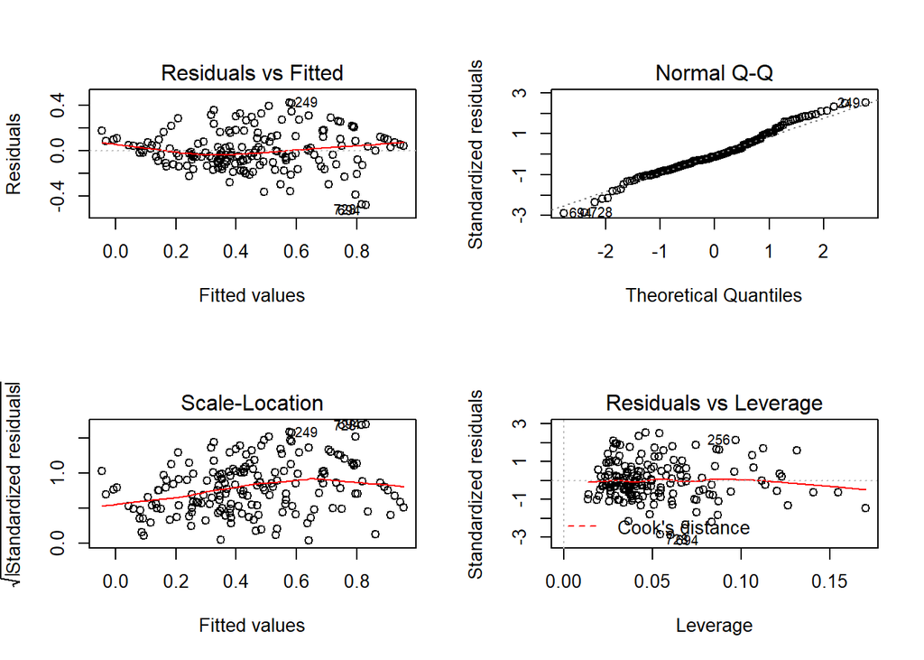

```r
par(mfrow=c(2,2))
plot(fit.cp.bic)
```

**Cp, BIC, and adjusted R-squared values**

```r
cat(resforward$cp[8])
```

```
## -12.93019
```

```r
cat(resforward$bic[8])
```

```
## -136.3232
```

```r
cat(resforward$adjr2[8])
```

```
## 0.6292293
```

**Validation set error**

```r
mean((predict(fit.cp.bic, newdata=crimeTesting) - crimeTesting$ViolentCrimesPerPop)^2)
```

```
## [1] 0.02798789
```

The validation set error is 2.799% for m1.

**LOOCV**

```r
library(boot)
glmfit.cp.bic <- glm(ViolentCrimesPerPop~state+PctUnemployed+PctHousLess3BR+PctVacantBoarded+PctHousNoPhone+NumStreet+RacialMatchCommPol+PctPolicBlack, data=crime)
LOOCV.cp.bic <- cv.glm(crime, glmfit.cp.bic)$delta[1]
print(LOOCV.cp.bic)
```

```
## [1] 0.02946906
```